# PBL Project Part 3, 4, and 5

Yin Lei & Lisa Spindler

2022-12-16

## Read Data

| Description | Temperature | Time(s) |
| --- | --- | --- |
| Reference | 25°C | 0 min |
| Mild heat shock | 37°C | 10 min, 30 min |
| Severe heat shock | 42°C | 10 min, 30 min |

Yeast types:

- Reference/Wildtype
- Knockdown: HSF1
- Knockout: MSN2/4
- Knockdown & Knockout: HSF1 and MSN2/4 (double)

$\implies$ 3 replicates of each condition

```r
library(tidyverse)

# read each file
complex_yeast_heatshock <- read_tsv("complex_yeast_heatshock.tsv")
sample_mapping <- read_tsv("sample_mapping.tsv")
flat_file <- read_tsv("yeastract2019-flat-file.tsv", col_names = F, na = c("", "NA", "N/A"))

# set column names for flat_file
names(flat_file) <- c("Regulator_systematic", "Regulator_standard",
                      "Target_systematic", "Target_standard",
                      "Id", "Date", "Environment", "Regulation", "Type", "Method")
```

## Get to know the data

First of all, we looked at the data including the mapping in order to get a basic understanding of the data.

### Difference between KO and KD

> “The **key difference** between gene knockout and knockdown is that the **gene knockout is a technique where the gene of interest is completely removed (inoperative state)** to study of functions of the gene while **gene knockdown is another technique where the gene of interest is silenced** to investigate the role of the particular gene in a biological system.”  
> —[Difference Between Gene Knockout and Knockdown | Compare the Difference Between Similar Terms](https://www.differencebetween.com/difference-between-gene-knockout-and-knockdown/)

### Observations on our data

- MSN2/4 is always KO
- HSF1 is always KD
- Wildtype $\to$ without any KO/KD
- Double $\to$ MSN2/4 & HSF1 both KO/KD
- Temperature in °C
- For each condition and strain: 3 replicates
- 25°C / 37°C / 42°C after certain times (0 min for 25°C; 10/30 min for heatshock)
- Gene expression data for each gene
- Flat file for interactions

### Get an impression of HSF1 and MSN2/4

#### HSF1

> “Trimeric heat shock transcription factor; activates multiple genes in response to highly diverse stresses and transient intracellular acidification; recognizes variable heat shock elements (HSEs) consisting of inverted NGAAN repeats; monitors translational status of cell through an RQC (Ribosomal Quality Control)-mediated translation-stress signal; involved in diauxic shift; posttranslationally regulated; human homolog HSF1 with linker region mutations can complement yeast hsf1 mutant”  
> —[Description of HSF1 / YGL073W | SGD](https://www.yeastgenome.org/locus/S000003041)

#### MSN2

> “Stress-responsive transcriptional activator; activated in stochastic pulses of nuclear localization in response to various stress conditions; binds DNA at stress response elements of responsive genes; light sensing pathway component that accumulates in the nucleus in response to blue light; relative distribution to nucleus increases upon DNA replication stress”  
> —[Description of MSN2 / YMR037C | SGD](https://www.yeastgenome.org/locus/S000004640)

#### MSN4

> “Stress-responsive transcriptional activator; activated in stochastic pulses of nuclear localization in response to various stress conditions; binds DNA at stress response elements of responsive genes, inducing gene expression; involved in diauxic shift”  
> —[Description of MSN4 / YKL062W | SGD](https://www.yeastgenome.org/locus/S000001545)

#### Diauxic shift - short explanation

> “The switch from rapid fermentative growth in the presence of a rich carbon source to slower exponential growth by aerobic respiration using ethanol once the preferred carbon source has been exhausted.”  
> —[Description of diauxic shift | SGD](https://www.yeastgenome.org/keyword/diauxic_shift)

> “A diauxic shift occurs when a microorganism is grown in a batch culture with two substrates. Rather than metabolizing the two available sugars simultaneously, microbial cells commonly consume them in a sequential pattern, resulting in two separate growth phases.

> When growing Saccharomyces cerevisiae with glucose and plenty of aeration, the diauxic growth pattern is commonly observed in a batch culture. During the first growth phase, when there is plenty of glucose and oxygen available, the yeast cells prefer glucose fermentation to aerobic respiration (crabtree effect). After glucose is depleted, the fermentation product ethanol is oxidised in a noticeably slower second growth phase, if oxygen is available.”  
> —[Diauxic shift - Labster Theory](https://theory.labster.com/diauxic-shift/)

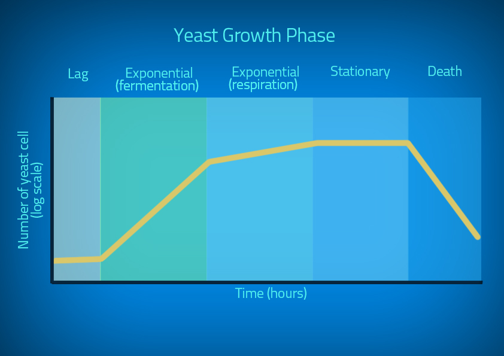

Typical growth curve of yeast in high glucose substrate. | Image Source: [Diauxic shift - Labster Theory](https://theory.labster.com/diauxic-shift/)

### Interaction overview with HSF1 & MSN2/4

```r
# filter flat file for interactions of interest (i.e. involving HSF1 or MSN2/4)
interactions <- flat_file %>%
  filter(Regulator_standard == "HSF1" | Target_standard == "HSF1" |
         Regulator_standard == "MSN2" | Target_standard == "MSN2" |
         Regulator_standard == "MSN4" | Target_standard == "MSN4") %>%
  select(Regulator_systematic, Regulator_standard,
         Target_systematic, Target_standard, Regulation) %>%
  mutate(Regulation = case_when(
    Regulation == "Positive" ~  1,
    Regulation == "Negative" ~ -1,
    TRUE                     ~  0
  ))

# reformat data
regulators <- interactions %>%
  select(Regulator_systematic, Regulator_standard) %>%
  distinct() %>%
  dplyr::rename(group = Regulator_systematic, id = Regulator_standard)
targets <- interactions %>%
  select(Target_systematic, Target_standard) %>%
  distinct() %>%
  dplyr::rename(group = Target_systematic, id = Target_standard)
nodes <- dplyr::union(regulators, targets)
edges <- interactions %>%
  select(Regulator_standard, Target_standard, Regulation) %>%
  dplyr::rename(source = Regulator_standard, target = Target_standard, weight = Regulation) %>%
  distinct()
```

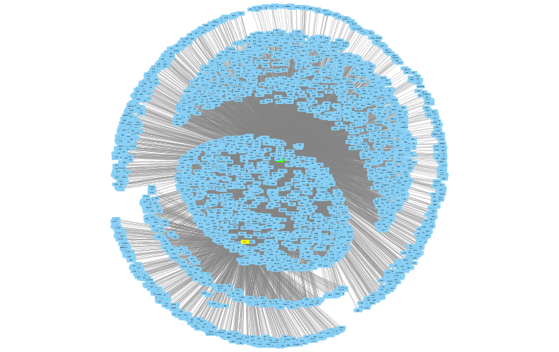

Interactions with HSF1 (yellow), MSN2 (green) and MSN4 (green) in yeast.

```r
library(RCy3)

# directly create an interaction network from the data frame
createNetworkFromDataFrames(nodes, edges)
setNodeColorBypass("HSF1", "#ffff00")
setNodeColorBypass("MSN2", "#33ff00")
setNodeColorBypass("MSN4", "#00ff33")
layoutNetwork("kamada-kawai")
saveSession("yeast_heatshock_interactions_from_df")
exportImage("yeast_heatshock_interactions_from_df")
```

This has been fun, but let’s try another approach, like in Felix’s Yeastract example on Moodle:

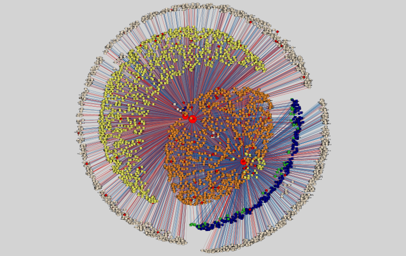

Interactions with HSF1 and MSN2/4 (major red octagons) in yeast: Regulators (red); only with HSF1, or MSN2, or MSN4 (beige); with both MSN2 and MSN4 (yellow); with HSF1 and MSN2 (dark blue); with HSF1 and MSN4 (green); with HSF1, and MSN2, and MSN4 (orange).

```r
library(igraph)

cyto_in <- edges %>%
  rename(V2 = source, V4 = target, reg = weight)

# go through igraph for extra node/edge attributes
gD <- igraph::simplify(igraph::graph.data.frame(cyto_in, directed = TRUE))
igraph::vcount(gD)
igraph::ecount(gD)
degAll <- igraph::degree(gD, v = igraph::V(gD), mode = "all")

betAll <- igraph::betweenness(gD, igraph::V(gD), directed = FALSE) /
  (((igraph::vcount(gD) - 1) * (igraph::vcount(gD) - 2)) / 2)
betAll.norm <- (betAll - min(betAll)) / (max(betAll) - min(betAll))
rm(betAll)

dsAll <- igraph::similarity.dice(gD, vids = igraph::V(gD), mode = "all")

gD <- igraph::set.vertex.attribute(gD, "degree", index = igraph::V(gD), value = degAll)
gD <- igraph::set.vertex.attribute(gD, "betweenness", index = igraph::V(gD), value = betAll.norm)

F1 <- function(x) {
  data.frame(SIM = dsAll[which(igraph::V(gD)$name == as.character(x$V2)),
                         which(igraph::V(gD)$name == as.character(x$V4))])
}
cyto_in.ext <- plyr::ddply(cyto_in, .variables = c("V2", "V4", "reg"),
                           function(x) data.frame(F1(x)))
gD <- igraph::set.edge.attribute(gD, "weight", index = igraph::E(gD), value = 0)
gD <- igraph::set.edge.attribute(gD, "similarity", index = igraph::E(gD), value = 0)

for (i in 1:nrow(cyto_in.ext)) {
  igraph::E(gD)[as.character(cyto_in.ext$V2) %--%
                as.character(cyto_in.ext$V4)]$weight <- as.numeric(cyto_in.ext$reg)
  igraph::E(gD)[as.character(cyto_in.ext$V2) %--%
                as.character(cyto_in.ext$V4)]$similarity <- as.numeric(cyto_in.ext$SIM)
}

cyto_u <- unique(cyto_in[c("V2", "V4")])
cyto_listed <- plyr::ddply(cyto_u, "V4", summarise,
                           regulated_by = paste(sort(V2), collapse = ","), .drop = FALSE)

igraph::V(gD)[cyto_listed$V4]$node_color <- cyto_listed$regulated_by

igraph::V(gD)[unique(cyto_in$V2)]$node_color <- "regulator"

igraph::V(gD)[unique(cyto_in$V4)]$node_shape <- "target"
igraph::V(gD)[unique(cyto_in$V2)]$node_shape <- "regulator"

createNetworkFromIgraph(gD)
nodes <- getTableColumns(table = "node")
layoutNetwork("kamada-kawai")

setNodeColorMapping("node_color",
                    c(NA, "regulator", "HSF1", "MSN2", "MSN4",
                      "MSN2,MSN4", "HSF1,MSN2", "HSF1,MSN4", "HSF1,MSN2,MSN4"),
                    c("#000000", "#ff0000", "#ffefd5", "#ffefd5", "#ffefd5",
                      "#ffff66", "#000099", "#33cc33", "#ff9933"),
                    mapping.type = "d")
lockNodeDimensions(TRUE)
setNodeSizeMapping("betweenness",
                   c(min(betAll.norm), mean(betAll.norm), max(betAll.norm)),
                   c(30, 60, 100))
setNodeShapeMapping("node_shape",
                    c("target", "regulator"),
                    c("RECTANGLE", "OCTAGON"))

setEdgeColorMapping("weight",
                    c(min(as.numeric(cyto_in$reg)), mean(as.numeric(cyto_in$reg)), max(as.numeric(cyto_in$reg))),
                    c("#cc0000", "#999999", "#0b5394"))

setBackgroundColorDefault("#d3d3d3")
setNodeBorderColorDefault("#000000")
setNodeBorderWidthDefault(3)
setNodeFontSizeDefault(20)
setNodeLabelColorDefault("#000000")

saveSession("yeast_heatshock_interactions_from_igraph")
exportImage("yeast_heatshock_interactions_from_igraph")
```

### Analysis: Heatmap (PART 5)